# About Dataset

### CONTEXT

The number of restaurants in New York is increasing day by day. Lots of students and busy professionals rely on those restaurants due to their hectic lifestyles. Online food delivery service is a great option for them. It provides them with good food from their favorite restaurants. A food aggregator company FoodHub offers access to multiple restaurants through a single smartphone app.

The app allows the restaurants to receive a direct online order from a customer. The app assigns a delivery person from the company to pick up the order after it is confirmed by the restaurant. The delivery person then uses the map to reach the restaurant and waits for the food package. Once the food package is handed over to the delivery person, he/she confirms the pick-up in the app and travels to the customer's location to deliver the food. The delivery person confirms the drop-off in the app after delivering the food package to the customer. The customer can rate the order in the app. The food aggregator earns money by collecting a fixed margin of the delivery order from the restaurants.

### OBJECTIVE

The food aggregator company has stored the data of the different orders made by the registered customers in their online portal. They want to analyze the data to get a fair idea about the demand of different restaurants which will help them in enhancing their customer experience. Suppose you are hired as a Data Scientist in this company and the Data Science team has shared some of the key questions that need to be answered. Perform the data analysis to find answers to these questions that will help the company to improve the business.

### Imports and Reading Data

```python
import pandas as pd
import numpy as np
import matplotlib.pyplot as plt
import seaborn as sns
import kaggle
```

```python
!kaggle datasets download -d ahsan81/food-ordering-and-delivery-app-dataset
```

```
food-ordering-and-delivery-app-dataset.zip: Skipping, found more recently modified local copy (use --force to force download)
```

```python
df = pd.read_csv("food-ordering-and-delivery-app-dataset.zip")
```

### Data Understanding

```python
# Looking at first 5 rows and structure of the dataframe
df.head()
```

|  | order_id | customer_id | restaurant_name | cuisine_type | cost_of_the_order | day_of_the_week | rating | food_preparation_time | delivery_time |
| --- | --- | --- | --- | --- | --- | --- | --- | --- | --- |
| 0 | 1477147 | 337525 | Hangawi | Korean | 30.75 | Weekend | Not given | 25 | 20 |
| 1 | 1477685 | 358141 | Blue Ribbon Sushi Izakaya | Japanese | 12.08 | Weekend | Not given | 25 | 23 |
| 2 | 1477070 | 66393 | Cafe Habana | Mexican | 12.23 | Weekday | 5 | 23 | 28 |
| 3 | 1477334 | 106968 | Blue Ribbon Fried Chicken | American | 29.20 | Weekend | 3 | 25 | 15 |
| 4 | 1478249 | 76942 | Dirty Bird to Go | American | 11.59 | Weekday | 4 | 25 | 24 |

```python
# Checking column names, number of rows, null values and data type.
df.info()
```

```
<class 'pandas.core.frame.DataFrame'>
RangeIndex: 1898 entries, 0 to 1897
Data columns (total 9 columns):
 #   Column                 Non-Null Count  Dtype
---  ------                 --------------  -----
 0   order_id               1898 non-null   int64
 1   customer_id            1898 non-null   int64
 2   restaurant_name        1898 non-null   object
 3   cuisine_type           1898 non-null   object
 4   cost_of_the_order      1898 non-null   float64
 5   day_of_the_week        1898 non-null   object
 6   rating                 1898 non-null   object
 7   food_preparation_time  1898 non-null   int64
 8   delivery_time          1898 non-null   int64
dtypes: float64(1), int64(4), object(4)
memory usage: 133.6+ KB
```

```python
# Detailed description of numeric variables
df.describe()
```

|  | order_id | customer_id | cost_of_the_order | food_preparation_time | delivery_time |
| --- | --- | --- | --- | --- | --- |
| count | 1.898000e+03 | 1898.000000 | 1898.000000 | 1898.000000 | 1898.000000 |
| mean | 1.477496e+06 | 171168.478398 | 16.498851 | 27.371970 | 24.161749 |
| std | 5.480497e+02 | 113698.139743 | 7.483812 | 4.632481 | 4.972637 |
| min | 1.476547e+06 | 1311.000000 | 4.470000 | 20.000000 | 15.000000 |
| 25% | 1.477021e+06 | 77787.750000 | 12.080000 | 23.000000 | 20.000000 |
| 50% | 1.477496e+06 | 128600.000000 | 14.140000 | 27.000000 | 25.000000 |
| 75% | 1.477970e+06 | 270525.000000 | 22.297500 | 31.000000 | 28.000000 |
| max | 1.478444e+06 | 405334.000000 | 35.410000 | 35.000000 | 33.000000 |

```python
# Detailed description of object variables
df.describe(include="object")
```

|  | restaurant_name | cuisine_type | day_of_the_week | rating |
| --- | --- | --- | --- | --- |
| count | 1898 | 1898 | 1898 | 1898 |
| unique | 178 | 14 | 2 | 4 |
| top | Shake Shack | American | Weekend | Not given |
| freq | 219 | 584 | 1351 | 736 |

### Data Preparation

```python
# Checking for nulls
df.isnull().sum()
```

```
order_id                 0
customer_id              0
restaurant_name          0
cuisine_type             0
cost_of_the_order        0
day_of_the_week          0
rating                   0
food_preparation_time    0
delivery_time            0
dtype: int64
```

No null values, but there are rows in the *rating* column with value "**Not given**". We will not drop them since they account for approximately 40% of the total dataframe.

```python
# Checking for duplicated values
df.duplicated().sum()
```

```
0
```

No duplicated values. Let's continue.

### Univariate Analysis

```python
# Create a function that groups all methods of interest and apply to each column of the dataframe
def column_describer(df, col):
    # Create an empty DataFrame
    result_df = pd.DataFrame(columns=["Value", "Count", "Percentage"])

    # Calculate value counts and percentages
    value_counts = df[col].value_counts(normalize=True).head(10)
    for i, v in value_counts.items():
        count = df[col].value_counts()[i]
        percentage = v * 100
        result_df = result_df.append({"Value": i, "Count": count, "Percentage": f"{percentage :.2f}%"}, ignore_index=True)

    # Add a row for unique values
    unique_values = df[col].nunique()
    result_df = result_df.append({"Value": "Unique Values", "Count": unique_values, "Percentage": ""}, ignore_index=True)

    return result_df
```

```python
df.columns
```

```
Index(['order_id', 'customer_id', 'restaurant_name', 'cuisine_type',
       'cost_of_the_order', 'day_of_the_week', 'rating',
       'food_preparation_time', 'delivery_time'],
      dtype='object')
```

#### order_id

```python
column_describer(df, "order_id")
```

|  | Value | Count | Percentage |
| --- | --- | --- | --- |
| 0 | 1476607 | 1 | 0.05% |
| 1 | 1477883 | 1 | 0.05% |
| 2 | 1477859 | 1 | 0.05% |
| 3 | 1477861 | 1 | 0.05% |
| 4 | 1477863 | 1 | 0.05% |
| 5 | 1477865 | 1 | 0.05% |
| 6 | 1477867 | 1 | 0.05% |
| 7 | 1477869 | 1 | 0.05% |
| 8 | 1477871 | 1 | 0.05% |
| 9 | 1477873 | 1 | 0.05% |
| 10 | Unique Values | 1898 |  |

All values are unique meaning the column performs as it should (one unique id per data entry).

#### customer_id

```python
column_describer(df, "customer_id")
```

|  | Value | Count | Percentage |
| --- | --- | --- | --- |
| 0 | 52832 | 13 | 0.68% |
| 1 | 47440 | 10 | 0.53% |
| 2 | 83287 | 9 | 0.47% |
| 3 | 250494 | 8 | 0.42% |
| 4 | 259341 | 7 | 0.37% |
| 5 | 65009 | 7 | 0.37% |
| 6 | 82041 | 7 | 0.37% |
| 7 | 276192 | 7 | 0.37% |
| 8 | 107909 | 6 | 0.32% |
| 9 | 60052 | 6 | 0.32% |
| 10 | Unique Values | 1200 |  |

For this column we have only 1200 unique values. We can see some customers are ordering more than once. We can create a feature to visualize the data.

```python
# Function to categorize order frequency of the customers
def customer_frequency(value):
    if value == 1:
        return "One order customer"
    elif value <=4:
        return "2 to 4 orders"
    else:
        return "Over 4 orders"
```

```python
# Apply the function to the frequency variable and get the count of each category, to plot it after
frequency = df["customer_id"].value_counts().apply(customer_frequency)
customer_freq = frequency.value_counts()
```

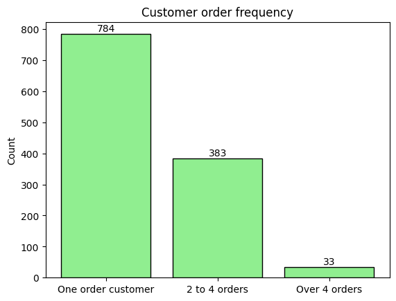

```python
fig, ax = plt.subplots()
x_values = customer_freq.index
y_values = customer_freq.values

ax.bar(x_values, y_values, color="lightgreen", edgecolor="black")

for x, y in zip(x_values, y_values):
    ax.annotate(f"{y}", xy=(x, y), xytext=(0, 1), textcoords="offset points", ha="center", va="bottom")

ax.set_title("Customer order frequency")
ax.set_ylabel("Count")
plt.show()
```

We can observe in this dataframe that the most frequent customer is the one that orders once, followed by the one with 2 to 4 orders.

#### restaurant_name

```python
column_describer(df, "restaurant_name")
```

|  | Value | Count | Percentage |
| --- | --- | --- | --- |
| 0 | Shake Shack | 219 | 11.54% |
| 1 | The Meatball Shop | 132 | 6.95% |
| 2 | Blue Ribbon Sushi | 119 | 6.27% |
| 3 | Blue Ribbon Fried Chicken | 96 | 5.06% |
| 4 | Parm | 68 | 3.58% |
| 5 | RedFarm Broadway | 59 | 3.11% |
| 6 | RedFarm Hudson | 55 | 2.90% |
| 7 | TAO | 49 | 2.58% |
| 8 | Han Dynasty | 46 | 2.42% |
| 9 | Blue Ribbon Sushi Bar & Grill | 44 | 2.32% |
| 10 | Unique Values | 178 |  |

We can plot to check top 30 restaurants.

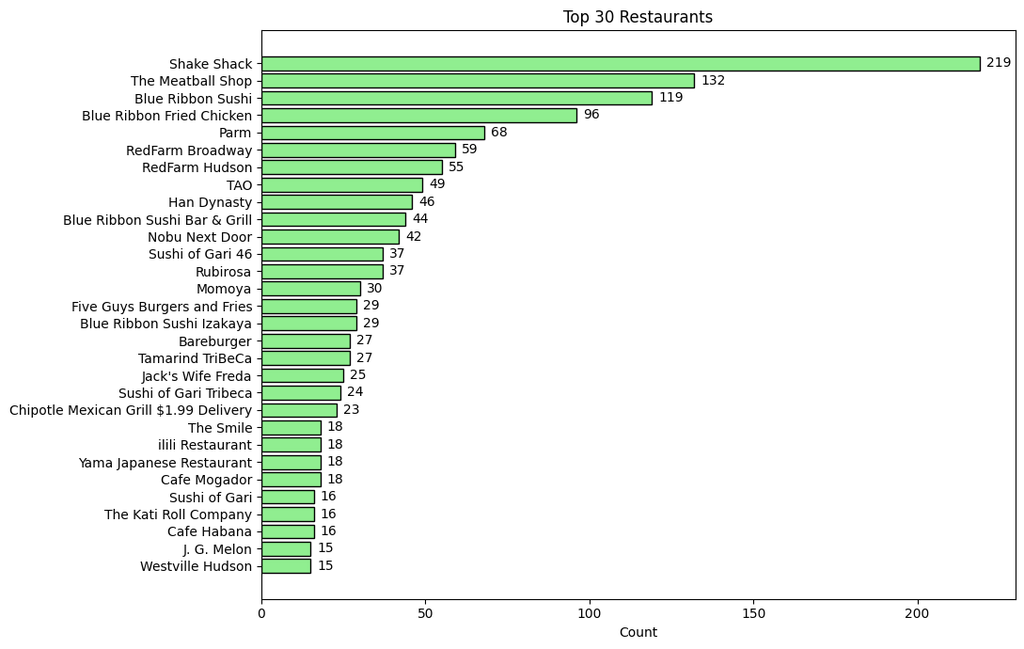

```python
fig, ax = plt.subplots(figsize=(11,7))

x_values = df["restaurant_name"].value_counts().head(30).sort_values().index
y_values = df["restaurant_name"].value_counts().head(30).sort_values().values

ax.barh(x_values,y_values, color="lightgreen", edgecolor="black")

for x, y in zip(x_values, y_values):
    ax.annotate(f"{y}", xy=(y, x), xytext=(5, 0), textcoords="offset points", ha="left", va="center")

ax.set_title("Top 30 Restaurants")
ax.set_xlabel("Count")

plt.tight_layout()
plt.show()
```

We can see the name **Blue Ribbon** and **RedFarm** several times, so maybe we can assume there can be several chain restaurants in the dataframe.

#### cuisine_type

```python
column_describer(df, "cuisine_type")
```

|  | Value | Count | Percentage |
| --- | --- | --- | --- |
| 0 | American | 584 | 30.77% |
| 1 | Japanese | 470 | 24.76% |
| 2 | Italian | 298 | 15.70% |
| 3 | Chinese | 215 | 11.33% |
| 4 | Mexican | 77 | 4.06% |
| 5 | Indian | 73 | 3.85% |
| 6 | Middle Eastern | 49 | 2.58% |
| 7 | Mediterranean | 46 | 2.42% |
| 8 | Thai | 19 | 1.00% |
| 9 | French | 18 | 0.95% |
| 10 | Unique Values | 14 |  |

14 unique values, being American the most frequent type of cuisine for ordering.

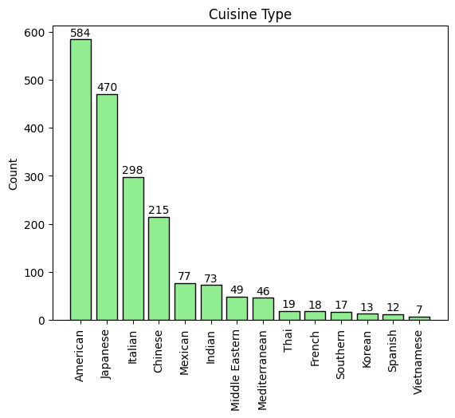

```python
fig, ax = plt.subplots()
x_values = df["cuisine_type"].value_counts().index
y_values = df["cuisine_type"].value_counts().values

ax.bar(x_values, y_values, color="lightgreen", edgecolor = "black")

for x, y in zip(x_values, y_values):
    ax.annotate(f"{y}", xy=(x, y), xytext=(0, 1), textcoords = "offset points", ha= "center", va= "bottom")

ax.tick_params(axis="x", labelrotation = 90)
ax.set_title("Cuisine Type")
ax.set_ylabel("Count")
plt.show()
```

#### cost_of_the_order

```python
column_describer(df, "cost_of_the_order")
```

|  | Value | Count | Percentage |
| --- | --- | --- | --- |
| 0 | 12.18 | 86 | 4.53% |
| 1 | 12.13 | 82 | 4.32% |
| 2 | 12.23 | 47 | 2.48% |
| 3 | 24.2 | 42 | 2.21% |
| 4 | 29.1 | 37 | 1.95% |
| 5 | 12.08 | 36 | 1.90% |
| 6 | 24.25 | 36 | 1.90% |
| 7 | 24.3 | 35 | 1.84% |
| 8 | 14.07 | 32 | 1.69% |
| 9 | 29.15 | 30 | 1.58% |
| 10 | Unique Values | 312 |  |

We can observe the most frequent costs of orders are around 12 dollars.

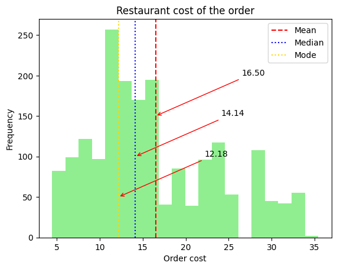

```python
fig, ax = plt.subplots()

ax.hist(df["cost_of_the_order"], color="lightgreen", bins = 20)

mean_value = df["cost_of_the_order"].mean()
median_value = df["cost_of_the_order"].median()
mode_value = df["cost_of_the_order"].mode()[0]

ax.axvline(mean_value, label="Mean", color="red", linestyle="dashed")
ax.axvline(median_value, label="Median", color="blue", linestyle="dotted")
ax.axvline(mode_value, label="Mode", color="gold", linestyle="dotted")

# Annotate the mode value

ax.annotate(f"{mean_value:.2f}", xy=(mean_value, 150), xytext=(mean_value + 10, 200),
             arrowprops=dict(arrowstyle="->", color="red"), fontsize=10)
ax.annotate(str(median_value), xy=(median_value, 100), xytext=(median_value + 10, 150),
             arrowprops=dict(arrowstyle="->", color="red"), fontsize=10)
ax.annotate(str(mode_value), xy=(mode_value, 50), xytext=(mode_value + 10, 100),
             arrowprops=dict(arrowstyle="->", color="red"), fontsize=10)

ax.legend()
ax.set_title("Restaurant cost of the order")
ax.set_xlabel("Order cost")
ax.set_ylabel("Frequency")
plt.show()
```

The mode for *cost_of_the_order* is 12.18 dollars yet the mean of the column is 16.50 dollars.

#### day_of_the_week

```python
column_describer(df, "day_of_the_week")
```

|  | Value | Count | Percentage |
| --- | --- | --- | --- |
| 0 | Weekend | 1351 | 71.18% |
| 1 | Weekday | 547 | 28.82% |
| 2 | Unique Values | 2 |  |

This should be considered as a categorical data type, for memory usage reduction and performance improvement matters, but since this is a small dataframe, we will just leave as an object data type.

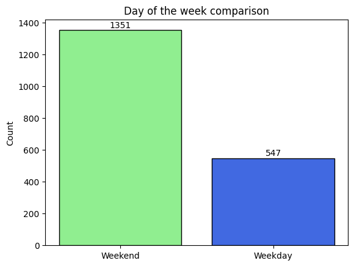

```python
fig, ax = plt.subplots()

x_values = df["day_of_the_week"].value_counts().index
y_values = df["day_of_the_week"].value_counts().values
ax.bar(x_values, y_values, color=["lightgreen", "royalblue"], edgecolor="black")


for x, y in zip(x_values, y_values):
    ax.annotate(f"{y}", xy = (x, y), xytext = (0, 1), textcoords = "offset points", ha = "center", va = "bottom")

ax.set_title("Day of the week comparison")
ax.set_ylabel("Count")
plt.show()
```

It is notable here that weekend if predominant over weekdays when it comes to ordering food.

#### rating

```python
column_describer(df, "rating")
```

|  | Value | Count | Percentage |
| --- | --- | --- | --- |
| 0 | Not given | 736 | 38.78% |
| 1 | 5 | 588 | 30.98% |
| 2 | 4 | 386 | 20.34% |
| 3 | 3 | 188 | 9.91% |
| 4 | Unique Values | 4 |  |

In the dataset, ratings are expected to fall within the range of 1 to 5. However, we observe values ranging from 3 to 5, along with an additional category labeled **"Not given"**. This label likely indicates that some customers chose not to provide a rating for their order. While there could be various reasons for this, the most possible explanation is that these customers **simply opted not to rate their experience**.

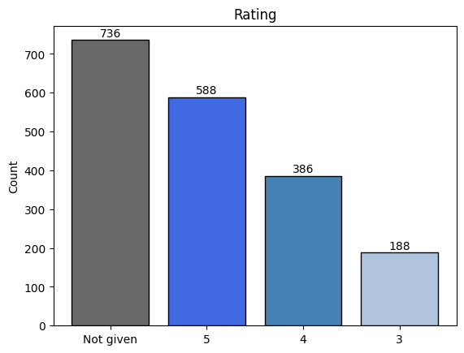

```python
fig, ax = plt.subplots()

x_values = df["rating"].value_counts().index
y_values = df["rating"].value_counts().values

ax.bar(x_values, y_values, color=["dimgray", "royalblue", "steelblue", "lightsteelblue"], edgecolor="black")

for x, y in zip(x_values, y_values):
    ax.annotate(f"{y}", xy = (x, y), xytext = (0, 1), textcoords = "offset points", ha = "center", va = "bottom")

ax.set_title("Rating")
ax.set_ylabel("Count")
plt.show()
```

The label **"Not given"** accounts for **38% of the total dataframe entries approximately**. Would not recommend dropping these values, at least for now.

#### food_preparation_time

```python
column_describer(df, "food_preparation_time")
```

|  | Value | Count | Percentage |
| --- | --- | --- | --- |
| 0 | 21 | 135 | 7.11% |
| 1 | 27 | 123 | 6.48% |
| 2 | 23 | 123 | 6.48% |
| 3 | 22 | 123 | 6.48% |
| 4 | 28 | 121 | 6.38% |
| 5 | 24 | 121 | 6.38% |
| 6 | 30 | 119 | 6.27% |
| 7 | 20 | 119 | 6.27% |
| 8 | 33 | 118 | 6.22% |
| 9 | 35 | 117 | 6.16% |
| 10 | Unique Values | 16 |  |

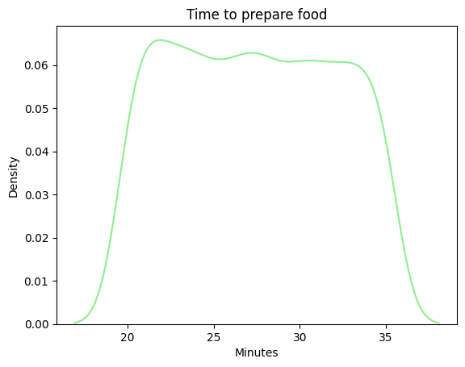

```python
fig, ax = plt.subplots()

sns.kdeplot(data=df["food_preparation_time"], ax=ax, color="lightgreen")

ax.set_title("Time to prepare food")
ax.set_xlabel("Minutes")
plt.show()
```

We can observe a somewhat distributed plot in the range of 20 to 35 minutes. Food preparation time seems to be constant in the whole dataset.

#### delivery_time

```python
column_describer(df, "delivery_time")
```

|  | Value | Count | Percentage |
| --- | --- | --- | --- |
| 0 | 24 | 162 | 8.54% |
| 1 | 29 | 148 | 7.80% |
| 2 | 28 | 148 | 7.80% |
| 3 | 26 | 141 | 7.43% |
| 4 | 27 | 138 | 7.27% |
| 5 | 30 | 133 | 7.01% |
| 6 | 25 | 120 | 6.32% |
| 7 | 16 | 90 | 4.74% |
| 8 | 19 | 90 | 4.74% |
| 9 | 20 | 88 | 4.64% |
| 10 | Unique Values | 19 |  |

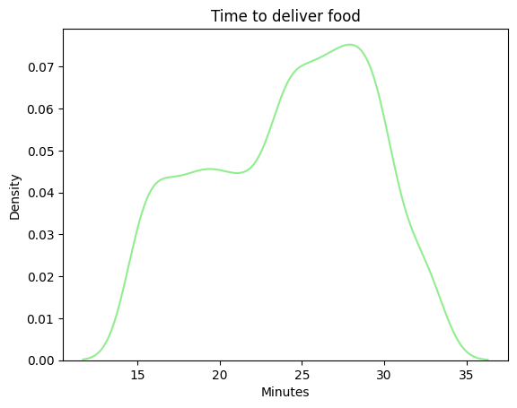

```python
fig, ax = plt.subplots()

sns.kdeplot(data=df["delivery_time"], ax=ax, color="lightgreen")

ax.set_title("Time to deliver food")
ax.set_xlabel("Minutes")
plt.show()
```

For the delivery time it seems to be more condensed in the range of 25 to 30 minutes.

### Multivariate Analysis

```python
df.head()
```

|  | order_id | customer_id | restaurant_name | cuisine_type | cost_of_the_order | day_of_the_week | rating | food_preparation_time | delivery_time |
| --- | --- | --- | --- | --- | --- | --- | --- | --- | --- |
| 0 | 1477147 | 337525 | Hangawi | Korean | 30.75 | Weekend | Not given | 25 | 20 |
| 1 | 1477685 | 358141 | Blue Ribbon Sushi Izakaya | Japanese | 12.08 | Weekend | Not given | 25 | 23 |
| 2 | 1477070 | 66393 | Cafe Habana | Mexican | 12.23 | Weekday | 5 | 23 | 28 |
| 3 | 1477334 | 106968 | Blue Ribbon Fried Chicken | American | 29.20 | Weekend | 3 | 25 | 15 |
| 4 | 1478249 | 76942 | Dirty Bird to Go | American | 11.59 | Weekday | 4 | 25 | 24 |

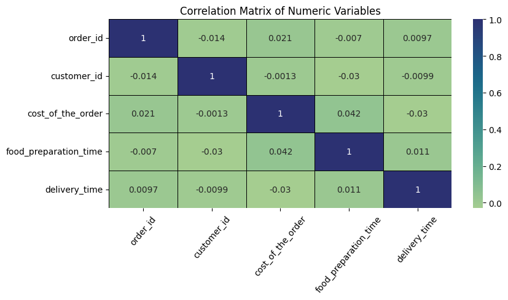

```python
fig, ax = plt.subplots(figsize=(9, 4))

sns.heatmap(data=df.corr(), cmap='crest', annot=True, linewidths=0.5, linecolor="black", ax=ax)

ax.set_xticklabels(ax.get_xticklabels(), rotation=50)

ax.set_title("Correlation Matrix of Numeric Variables")

plt.show()
```

There seems to be no correlation between the numeric variables.

```python
# Create a groupby to check restaurants where a single customer has placed multiple orders.
customer_order = df.groupby(["customer_id", "restaurant_name"]).agg(
times_ordered = ("restaurant_name", "count")).sort_values(by="times_ordered", ascending=False).head(20)
customer_order
```

| customer_id | restaurant_name | times_ordered |
| --- | --- | --- |
| 97991 | Blue Ribbon Sushi Bar & Grill | 6 |
| 47440 | Bareburger | 6 |
| 97806 | Shake Shack | 5 |
| 84087 | The Meatball Shop | 5 |
| 270525 | The Smile | 4 |
| 276192 | Sushi of Gari Tribeca | 4 |
| 331143 | Waverly Diner | 4 |
| 87006 | Nobu Next Door | 4 |
| 318451 | Blue Ribbon Sushi | 4 |
| 177078 | Lantern Thai Kitchen | 4 |
| 79215 | Blue Ribbon Sushi | 4 |
| 47440 | Blue Ribbon Fried Chicken | 4 |
| 117810 | Momoya | 4 |
| 183520 | Blue Ribbon Sushi | 4 |
| 97079 | Benihana | 4 |
| 186473 | Blue Ribbon Sushi | 4 |
| 142461 | Shake Shack | 4 |
| 60052 | RedFarm Broadway | 4 |
| 385150 | Blue Ribbon Sushi | 4 |
| 83287 | Blue Ribbon Sushi Izakaya | 4 |

```python
customer_order.groupby("restaurant_name")["times_ordered"].sum().sort_values(ascending=False).reset_index()
```

|  | restaurant_name | times_ordered |
| --- | --- | --- |
| 0 | Blue Ribbon Sushi | 20 |
| 1 | Shake Shack | 9 |
| 2 | Blue Ribbon Sushi Bar & Grill | 6 |
| 3 | Bareburger | 6 |
| 4 | The Meatball Shop | 5 |
| 5 | Waverly Diner | 4 |
| 6 | The Smile | 4 |
| 7 | Sushi of Gari Tribeca | 4 |
| 8 | RedFarm Broadway | 4 |
| 9 | Nobu Next Door | 4 |
| 10 | Momoya | 4 |
| 11 | Lantern Thai Kitchen | 4 |
| 12 | Blue Ribbon Sushi Izakaya | 4 |
| 13 | Blue Ribbon Fried Chicken | 4 |
| 14 | Benihana | 4 |

In the provided table, we observe instances where a single customer has placed multiple orders. Notably, the **Blue Ribbon** chain restaurant stands out. Considering this pattern, it may be prudent to explore marketing strategies and promotional offers specifically for the **Blue Ribbon** establishment.

Let's take a closer look at the **Blue Ribbon** chain restaurant.

```python
# Group all the restaurants named Blue Ribbon
blue_ribbon = df[df["restaurant_name"].str.contains("Blue Ribbon")]
```

```python
# Make a summary table of the Blue Ribbon chain restaurant
blue_ribbon_summary = blue_ribbon.groupby(["restaurant_name", "cuisine_type"]).agg(
    times_ordered = ("order_id", "count"),
    prep_time = ("food_preparation_time", "mean"),
    time_deliver = ("delivery_time", "mean"),
    weekend = pd.NamedAgg("day_of_the_week", lambda x: (x == "Weekend").sum()),
    weekday = pd.NamedAgg("day_of_the_week", lambda x: (x == "Weekday").sum()),
    cost = ("cost_of_the_order", "mean")
).reset_index()
blue_ribbon_summary
```

|  | restaurant_name | cuisine_type | times_ordered | prep_time | time_deliver | weekend | weekday | cost |
| --- | --- | --- | --- | --- | --- | --- | --- | --- |
| 0 | Blue Ribbon Brooklyn | American | 4 | 27.250000 | 23.500000 | 2 | 2 | 16.530000 |
| 1 | Blue Ribbon Fried Chicken | American | 96 | 27.197917 | 24.145833 | 74 | 22 | 17.315521 |
| 2 | Blue Ribbon Sushi | Japanese | 119 | 27.924370 | 23.941176 | 85 | 34 | 15.999580 |
| 3 | Blue Ribbon Sushi Bar & Grill | Japanese | 44 | 26.295455 | 23.409091 | 29 | 15 | 15.150455 |
| 4 | Blue Ribbon Sushi Izakaya | Japanese | 29 | 28.724138 | 23.482759 | 21 | 8 | 16.727241 |

The **Blue Ribbon** chain comprises five restaurants, with two specializing in American cuisine and the remaining three offering Japanese food. The preparation and delivery times, as well as the cost of orders, appear to be within the expected norms. Notably, orders from all Blue Ribbon restaurants account for 292 out of 1898 entries, approximately **15% of the total dataframe**.

It would be good to check the other outstanding chain restaurant **RedFarm**.

```python
# Group all the restaurants named RedFarm
red_farm = df[df["restaurant_name"].str.contains("RedFarm")]
```

```python
# Make a summary table of the RedFarm chain restaurant
red_farm_summary = red_farm.groupby(["restaurant_name", "cuisine_type"]).agg(
    times_ordered = ("order_id", "count"),
    prep_time = ("food_preparation_time", "mean"),
    time_deliver = ("delivery_time", "mean"),
    weekend = pd.NamedAgg("day_of_the_week", lambda x: (x == "Weekend").sum()),
    weekday = pd.NamedAgg("day_of_the_week", lambda x: (x == "Weekday").sum()),
    cost = ("cost_of_the_order", "mean")
).reset_index()
red_farm_summary
```

|  | restaurant_name | cuisine_type | times_ordered | prep_time | time_deliver | weekend | weekday | cost |
| --- | --- | --- | --- | --- | --- | --- | --- | --- |
| 0 | RedFarm Broadway | Chinese | 59 | 27.593220 | 23.152542 | 44 | 15 | 16.358136 |
| 1 | RedFarm Hudson | Chinese | 55 | 27.163636 | 24.200000 | 44 | 11 | 16.749273 |

The **RedFarm** chain comprises two Chinese restaurants, which collectively represent 114 out of 1898 entries in the dataset, approximately constituting **6% of the total dataframe**.

```python
# Checking 2 of the most frequent to buy restaurants
df.groupby("restaurant_name").agg(
    shake_shack = pd.NamedAgg("restaurant_name", lambda x: (x == "Shake Shack").sum()),
    meatball_shop = pd.NamedAgg("restaurant_name", lambda x: (x == "The Meatball Shop").sum())
).sort_values(by=["shake_shack", "meatball_shop"], ascending=False).head(2)
```

| restaurant_name | shake_shack | meatball_shop |
| --- | --- | --- |
| Shake Shack | 219 | 0 |
| The Meatball Shop | 0 | 132 |

The **Blue Ribbon** chain restaurant, **Shake Shack**, **The Meatball Shop**, and the **RedFarm** chain restaurant collectively represent 757 out of 1898 entries, approximately constituting 40% of the total dataframe. This information is noteworthy, as these establishments are the most frequent in terms of orders.

```python
# Filtering top customers
top_customers = df['customer_id'].value_counts().head(20).index
```

```python
# Creating a top 20 customers variable for visualization purposes
top_20_customers = df[df['customer_id'].isin(top_customers)]
```

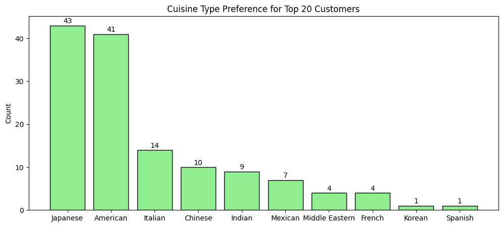

```python
fig, ax = plt.subplots(figsize=(12,5))

x_values = top_20_customers["cuisine_type"].value_counts().index
y_values = top_20_customers["cuisine_type"].value_counts().values

ax.bar(x_values, y_values, color="lightgreen", edgecolor="black")

for x, y in zip(x_values, y_values):
    ax.annotate(f"{y}", xy= (x, y), xytext= (0, 1), textcoords = "offset points", ha= "center", va= "bottom")

ax.set_ylabel("Count")
ax.set_title("Cuisine Type Preference for Top 20 Customers")
plt.show()
```

Top customers exhibit a preference for **Japanese cuisine**, closely followed by **American food**. Conversely, Spanish and Korean dishes appear to be less frequently ordered. This trend may be influenced by cultural factors, individual culinary preferences, or a relative unfamiliarity with certain cuisines.

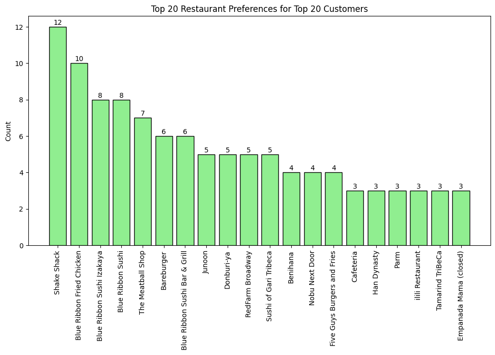

```python
fig, ax = plt.subplots(figsize=(12,6))

x_values = top_20_customers["restaurant_name"].value_counts().head(20).index
y_values = top_20_customers["restaurant_name"].value_counts().head(20).values

ax.bar(x_values, y_values, color="lightgreen", edgecolor="black")

# plt.figure(figsize=(12,4))
# top_20_customers["restaurant_name"].value_counts().head(20).plot(kind="bar", color="lightgreen", edgecolor="black")

for x, y in zip(x_values, y_values):
    ax.annotate(f"{y}", xy=(x, y), xytext=(0, 1), textcoords="offset points", ha="center", va="bottom")

ax.tick_params(axis="x", rotation=90)
ax.set_ylabel("Count")
ax.set_title("Top 20 Restaurant Preferences for Top 20 Customers")
plt.show()
```

While customers exhibit a preference for Japanese cuisine over American fare, it is noteworthy that the **Shake Shack**, an American-style restaurant, receives the highest number of orders.

```python
# Filtering top restaurants
top_restaurants = df["restaurant_name"].value_counts().head(50).index
```

```python
# Filtering top 50 restaurants and save it in a variable
top_50_restaurants = df[df["restaurant_name"].isin(top_restaurants)]
```

```python
# Function to group costs in range of values
def cost_category(value):
    if (value) <= 5 :
        return "0-5$"
    elif (value) <= 10 :
        return "6-10$"
    elif (value) <= 15 :
        return "11-15$"
    elif (value) <= 20 :
        return "16-20$"
    elif (value) <= 25 :
        return "21-25$"
    elif (value) <= 30 :
        return "26-30$"
    else:
        return "Over 30$"
```

```python
# Create a variable to order the categories
category_order = pd.CategoricalDtype(
    ["0-5$", "6-10$", "11-15$", "16-20$", "21-25$", "26-30$", "Over 30$"],
    ordered=True)
```

```python
# Store the results of the function apply to the cost_of_the_order column in a variable
category_cost = df["cost_of_the_order"].apply(cost_category).astype(category_order)
```

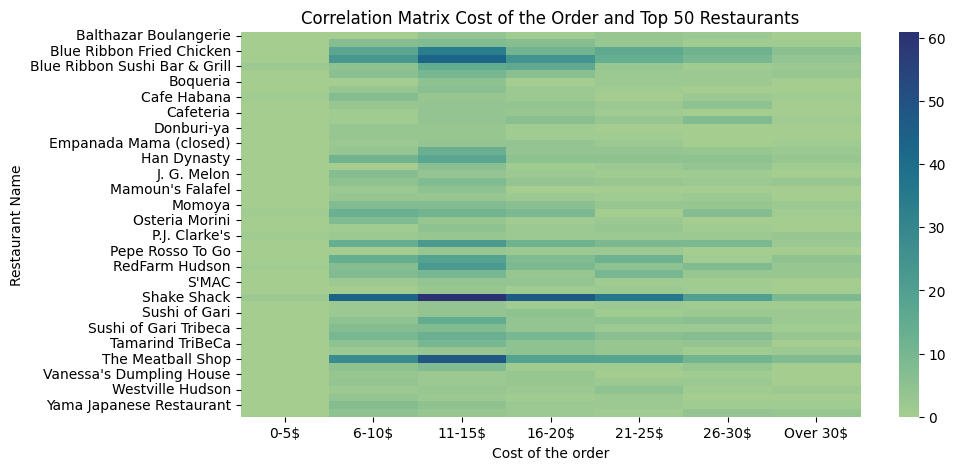

```python
fig, ax = plt.subplots(figsize=(10,5))

sns.heatmap(pd.crosstab(top_50_restaurants["restaurant_name"], category_cost), cmap="crest", ax=ax)

ax.set_xlabel("Cost of the order")
ax.set_ylabel("Restaurant Name")
ax.set_title("Correlation Matrix Cost of the Order and Top 50 Restaurants")
plt.show()
```

Top restaurants provide dining experiences within the price range of 6 to 20 dollars. However, it is worth noting that certain orders exceeding 20 dollars are discernible in the heatmap.

```python
# Sorting cuisine_type by the mean of cost_of_the_order
cost_order = df.groupby("cuisine_type")["cost_of_the_order"].median().sort_values().index
```

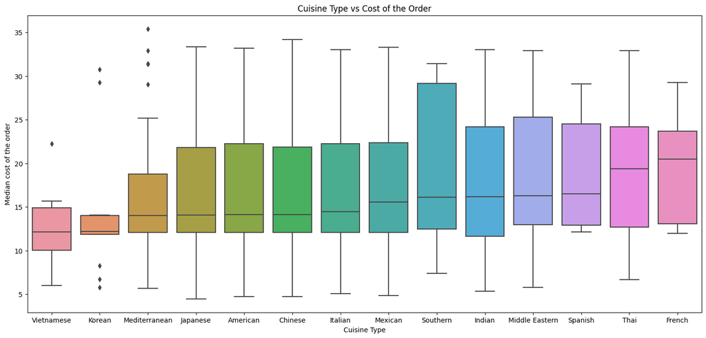

```python
# Plotting and sorting by the previous variable
fig, ax = plt.subplots(figsize=(18, 8))

sns.boxplot(data=df, x="cuisine_type", y="cost_of_the_order", order=cost_order, ax=ax)

ax.set_xlabel("Cuisine Type")
ax.set_ylabel("Median cost of the order")
ax.set_title("Cuisine Type vs Cost of the Order")
plt.show()
```

It is evident that Vietnamese and Korean cuisines are the most economical, while French cuisine stands out as the most expensive. Notably, there exist some outliers within the more affordable cuisine categories. These anomalies may be attributed to specialized dishes offered by certain restaurants, which can command higher prices.

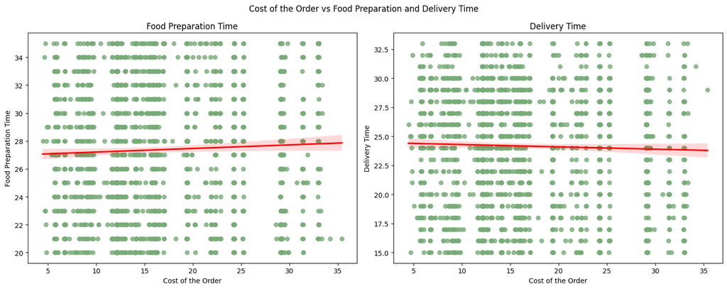

```python
fig, axs = plt.subplots(1, 2, figsize=(15, 6))

# First plot
sns.regplot(data=df, x= "cost_of_the_order", y= "food_preparation_time", color="#78ab78", line_kws={"color": "r"}, ax=axs[0])

axs[0].set_xlabel("Cost of the Order")
axs[0].set_ylabel("Food Preparation Time")
axs[0].set_title("Food Preparation Time")

# Second plot
sns.regplot(data=df, x= "cost_of_the_order", y= "delivery_time", color="#78ab78", line_kws={"color": "r"}, ax=axs[1])

axs[1].set_xlabel("Cost of the Order")
axs[1].set_ylabel("Delivery Time")
axs[1].set_title("Delivery Time")

plt.suptitle("Cost of the Order vs Food Preparation and Delivery Time")
plt.tight_layout()
plt.show()
```

We observe a lack of significant correlation between the **cost of an order** and the **food preparation and delivery time**. Contrary to expectations, **higher preparation and delivery times do not necessarily correspond to higher prices**. These extended times may be attributed to internal factors within the restaurant, such as increased demand or other operational considerations.

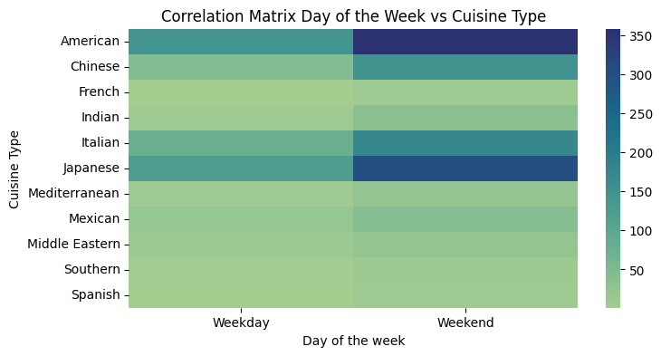

```python
fig, ax = plt.subplots(figsize=(8,4))

sns.heatmap(pd.crosstab(top_50_restaurants["cuisine_type"], top_50_restaurants["day_of_the_week"]), cmap="crest", ax=ax)

ax.set_xlabel("Day of the week")
ax.set_ylabel("Cuisine Type")
ax.set_title("Correlation Matrix Day of the Week vs Cuisine Type")
plt.show()
```

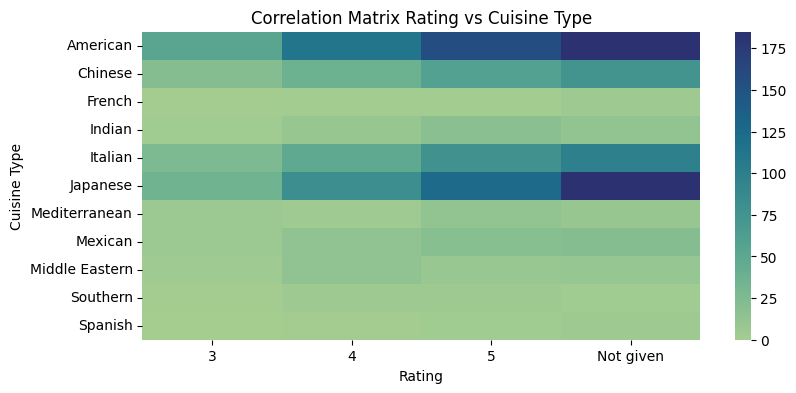

```python
fig, ax = plt.subplots(figsize=(9,4))

sns.heatmap(pd.crosstab(top_50_restaurants["cuisine_type"], top_50_restaurants["rating"]), cmap="crest", ax=ax)

ax.set_xlabel("Rating")
ax.set_ylabel("Cuisine Type")
ax.set_title("Correlation Matrix Rating vs Cuisine Type")
plt.show()
```

The majority of orders occur during the weekend. Several factors may contribute to this trend. Customers often choose to utilize their leisure time during weekends for relaxation or minimal activity, which could explain the increase in orders during this period.

The prevalence of “Not given” ratings is notable. Leveraging ratings as a valuable indicator, the food aggregator company could enhance the overall customer experience.

```python
# Creating order variables for the plots
food_preparation_order = df.groupby("cuisine_type")["food_preparation_time"].median().sort_values().index
delivery_order = df.groupby("cuisine_type")["delivery_time"].median().sort_values().index
```

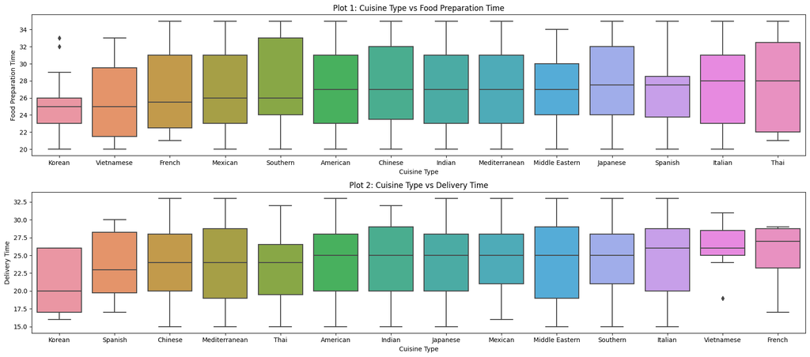

```python
fig, axs = plt.subplots(2,1, figsize=(18,8))

# Plot # 1
sns.boxplot(data=df, x="cuisine_type", y="food_preparation_time", order=food_preparation_order, ax=axs[0])
axs[0].set_xlabel("Cuisine Type")
axs[0].set_ylabel("Food Preparation Time")
axs[0].set_title("Plot 1: Cuisine Type vs Food Preparation Time")

# Plot # 2
sns.boxplot(data=df, x="cuisine_type", y="delivery_time", order=delivery_order, ax=axs[1])
axs[1].set_xlabel("Cuisine Type")
axs[1].set_ylabel("Delivery Time")
axs[1].set_title("Plot 2: Cuisine Type vs Delivery Time")

plt.tight_layout()
plt.show()
```

In both scenarios, the **Korean cuisine type consistently exhibits the shortest preparation and delivery times**. However, there are instances where preparation times deviate from the norm, as indicated by the outliers in Plot 1. This information is valuable for the food aggregator company, suggesting that strategic measures could be implemented to **.maximize Korean cuisine orders**.

```python
revenues = df.groupby(["restaurant_name", "cuisine_type"]).agg(
    Revenues = ("cost_of_the_order", "sum")
).sort_values(by="Revenues", ascending=False).head(20)
revenues
```

| restaurant_name | cuisine_type | Revenues |
| --- | --- | --- |
| Shake Shack | American | 3579.53 |
| Blue Ribbon Sushi | Japanese | 1903.95 |
| The Meatball Shop | Italian | 1821.01 |
| Blue Ribbon Fried Chicken | American | 1662.29 |
| Parm | Italian | 1112.76 |
| RedFarm Broadway | Chinese | 965.13 |
| RedFarm Hudson | Chinese | 921.21 |
| TAO | Japanese | 834.50 |
| Han Dynasty | Chinese | 755.29 |
| Blue Ribbon Sushi Bar & Grill | Japanese | 666.62 |
| Rubirosa | Italian | 660.45 |
| Sushi of Gari 46 | Japanese | 640.87 |
| Nobu Next Door | Japanese | 623.67 |
| Five Guys Burgers and Fries | American | 506.47 |
| Momoya | Japanese | 492.13 |
| Chipotle Mexican Grill $1.99 Delivery | Mexican | 491.69 |
| Blue Ribbon Sushi Izakaya | Japanese | 485.09 |
| Tamarind TriBeCa | Indian | 426.71 |
| Jack's Wife Freda | Mediterranean | 416.75 |
| Bareburger | American | 399.74 |

**Shake Shack** stands out as the restaurant with the highest revenue. Additionally, the **Blue Ribbon** and **RedFarm** chain restaurants, along with The Meatball Shop, also contribute significantly to the overall revenue. Notably, the revenue generated by Italian restaurants is prominently displayed in the table.

```python
# Filtering the dataframe by the numeric variables of the rating column and casting them to numeric type
numeric_rating = df[df["rating"] != "Not given"].copy()
numeric_rating["rating"] = numeric_rating["rating"].astype("int64")
```

```python
numeric_rating.groupby("cuisine_type")["rating"].mean().sort_values(ascending=False).reset_index()
```

|  | cuisine_type | rating |
| --- | --- | --- |
| 0 | Spanish | 4.833333 |
| 1 | Thai | 4.666667 |
| 2 | Indian | 4.540000 |
| 3 | Mexican | 4.416667 |
| 4 | Japanese | 4.373626 |
| 5 | Italian | 4.360465 |
| 6 | Chinese | 4.338346 |
| 7 | Southern | 4.307692 |
| 8 | French | 4.300000 |
| 9 | American | 4.298913 |
| 10 | Middle Eastern | 4.235294 |
| 11 | Mediterranean | 4.218750 |
| 12 | Korean | 4.111111 |
| 13 | Vietnamese | 4.000000 |

Spanish cuisine exhibits the highest ratings, a noteworthy observation. It is prudent to take into account that Spanish cuisine constitutes merely **12 out of 1898 entries**, approximately **0.6% of the total dataset**. As the number of entries increases, ratings may tend to decrease.

```python
# Store total rating per restaurant in a variable
rating_count = numeric_rating.groupby("restaurant_name")["rating"].count().sort_values(ascending=False).reset_index()
```

```python
# Get the top 30 total rating and store in variable
rating_count_30 = rating_count[rating_count["rating"] > 30]["restaurant_name"]
```

```python
# Out of the top 30 most rated restaurants, get the highest average rating and sort it from highest to lowest
top_rating = numeric_rating[numeric_rating["restaurant_name"].isin(rating_count_30)]
top_rating.groupby(["restaurant_name", "cuisine_type"])["rating"].mean().sort_values(ascending=False).reset_index()
```

|  | restaurant_name | cuisine_type | rating |
| --- | --- | --- | --- |
| 0 | The Meatball Shop | Italian | 4.528571 |
| 1 | The Meatball Shop | American | 4.428571 |
| 2 | Blue Ribbon Fried Chicken | American | 4.328125 |
| 3 | Shake Shack | American | 4.278195 |
| 4 | RedFarm Broadway | Chinese | 4.243902 |
| 5 | Blue Ribbon Sushi | Japanese | 4.219178 |
| 6 | RedFarm Hudson | Chinese | 4.176471 |
| 7 | Parm | Italian | 4.128205 |

- **The Meatball Shop**: While it holds the highest rating, it is intriguing that there exist two distinct Meatball Shop restaurants.
- The **Blue Ribbon** and **RedFarm** chain restaurants, previously identified, also stands, as does **Shake Shack**.

This information is of considerable interest to the food aggregator company. Notably, the restaurants with the highest frequency of ratings consistently maintain average ratings exceeding 4.

Let's look for **The Meatball Shop**:

```python
meatball = df[df["restaurant_name"] == "The Meatball Shop"]
```

```python
meatball.groupby("cuisine_type")["cuisine_type"].count()
```

```
cuisine_type
American     20
Italian     112
Name: cuisine_type, dtype: int64
```

It appears there might be an inconsistency in the data. The Meatball Shop is indeed a registered trademark, and while there may be multiple restaurants in New York City, they all fall under the same trademark. This clarification is essential for accurate analysis.

```python
# Group data by cuisine type and aggregate individual ratings
cuisine_rates = numeric_rating.groupby("cuisine_type").agg(
    rate_3 = pd.NamedAgg("rating", lambda x: (x == 3).sum()),
    rate_4 = pd.NamedAgg("rating", lambda x: (x == 4).sum()),
    rate_5 = pd.NamedAgg("rating", lambda x: (x == 5).sum())).sort_values(by="rate_5", ascending=False)
```

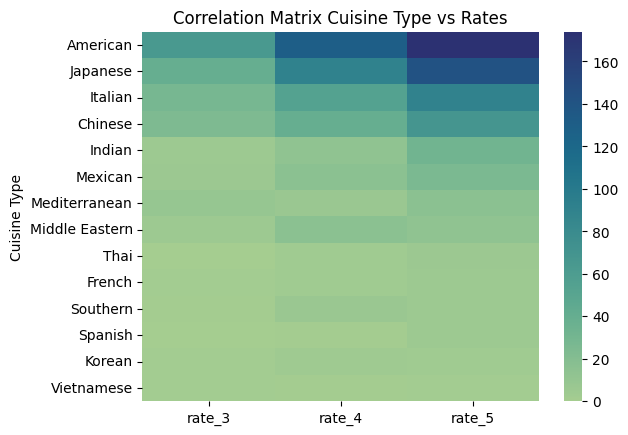

```python
fig, ax = plt.subplots()

sns.heatmap(cuisine_rates, cmap="crest", ax=ax)

ax.set_ylabel("Cuisine Type")
ax.set_title("Correlation Matrix Cuisine Type vs Rates")
plt.show()
```

American, Japanese, Italian and Chinese has the most 5 rates.

```python
# Group data by restaurant name and aggregate its individual ratings
restaurant_rates = numeric_rating.groupby("restaurant_name").agg(
    rate_3 = pd.NamedAgg("rating", lambda x: (x == 3).sum()),
    rate_4 = pd.NamedAgg("rating", lambda x: (x == 4).sum()),
    rate_5 = pd.NamedAgg("rating", lambda x: (x == 5).sum())).sort_values(by="rate_5", ascending=False).head(20)
```

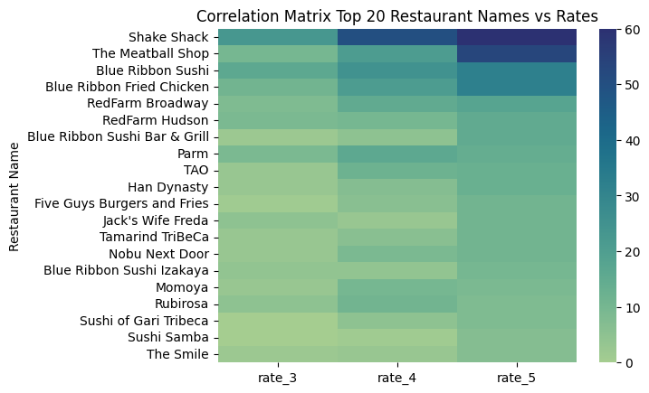

```python
fig, ax = plt.subplots()

sns.heatmap(restaurant_rates, cmap="crest", ax=ax)
ax.set_ylabel("Restaurant Name")
ax.set_title("Correlation Matrix Top 20 Restaurant Names vs Rates")
plt.show()
```

The Shake Shack stands top with highest 5 rates.

```python
# Group by day of the week and aggregate its individual ratings
day_rates = numeric_rating.groupby("day_of_the_week").agg(
    rate_3 = pd.NamedAgg("rating", lambda x: (x == 3).sum()),
    rate_4 = pd.NamedAgg("rating", lambda x: (x == 4).sum()),
    rate_5 = pd.NamedAgg("rating", lambda x: (x == 5).sum())).sort_values(by="rate_5", ascending=False)
```

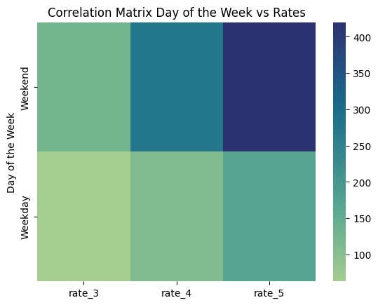

```python
fig, ax = plt.subplots()

sns.heatmap(day_rates, cmap="crest", ax=ax)
ax.set_ylabel("Day of the Week")
ax.set_title("Correlation Matrix Day of the Week vs Rates")
plt.show()
```

On weekends, ratings tend to be higher. However, this correlation could be influenced by the higher volume of orders during weekends compared to weekdays.

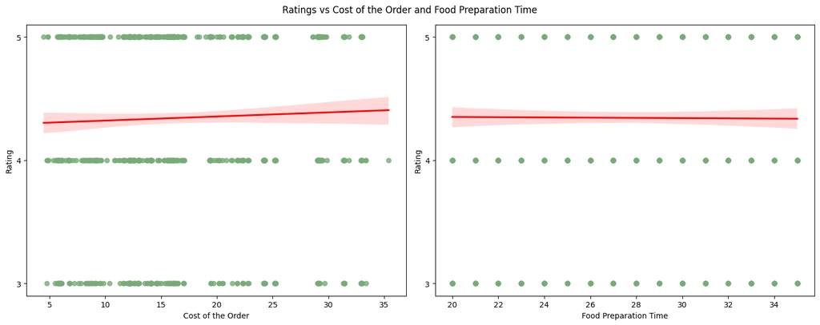

```python
fig, axs = plt.subplots(1, 2, figsize=(15, 6))

# First plot
sns.regplot(data=numeric_rating, x= "cost_of_the_order", y= "rating", color="#78ab78", line_kws={"color": "r"}, ax=axs[0])

axs[0].set_xlabel("Cost of the Order")
axs[0].set_ylabel("Rating")
axs[0].set_yticks([3, 4, 5])

# Second plot
sns.regplot(data=numeric_rating, x= "food_preparation_time", y= "rating", color="#78ab78", line_kws={"color": "r"}, ax=axs[1])

axs[1].set_xlabel("Food Preparation Time")
axs[1].set_ylabel("Rating")
axs[1].set_yticks([3, 4, 5])

plt.suptitle("Ratings vs Cost of the Order and Food Preparation Time")
plt.tight_layout()
plt.show()
```

It is notable that there isn’t a strong connection between **customer ratings and either the cost of an order or the food preparation time**. In this case, **higher ratings don’t necessarily mean lower costs or quicker preparation**. Other factors seem to influence ratings beyond these basic metrics. Further investigation is needed to fully understand these dynamics.

Lastly, let's create a feature called **total_time**.

```python
# Create a feature called total_time
total_time = df.copy()
total_time["total_time"] = total_time["food_preparation_time"] + total_time["delivery_time"]
```

```python
top_restaurants_time = df["restaurant_name"].value_counts().head(30).index
top_30_restaurants_time = total_time[total_time["restaurant_name"].isin(top_restaurants_time)].sort_values(by="total_time")
```

```python
# Create a function that groups total time
def time_category(value):
    if (value) <= 40 :
        return "< 40 minutes"
    elif (value) <= 50 :
        return "41- 50 minutes"
    elif (value) <= 60 :
        return "51 - 60 minutes"
    else:
        return "Over 60 minutes"
```

```python
# Order the values of the categories
time_order = pd.CategoricalDtype(
    ["< 40 minutes", "41- 50 minutes", "51 - 60 minutes", "Over 60 minutes"],
    ordered=True)
```

```python
# Apply the function created
category_time = top_30_restaurants_time["total_time"].apply(time_category).astype(time_order)
```

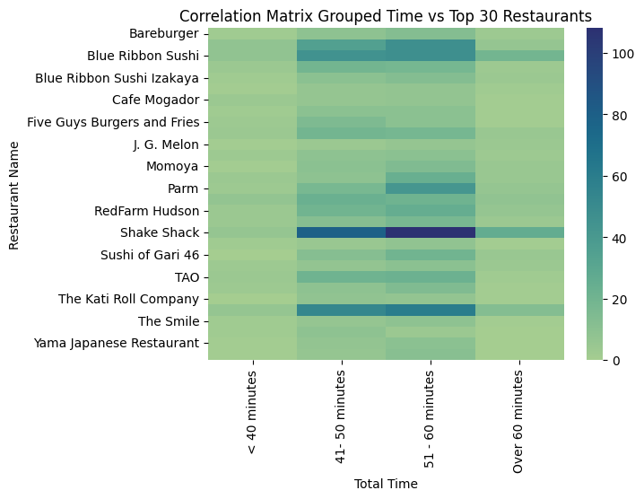

```python
fig, ax = plt.subplots()

sns.heatmap(pd.crosstab(top_30_restaurants_time["restaurant_name"], category_time), cmap="crest", ax=ax)

ax.set_xlabel("Total Time")
ax.set_ylabel("Restaurant Name")
ax.set_title("Correlation Matrix Grouped Time vs Top 30 Restaurants")
plt.show()
```

The majority of orders fall within the **41-50 minutes** and **51-60 minutes** time intervals. Typically, orders take approximately **40 to 60 minutes** from placement to delivery. However, there are instances where the total time exceeds 60 minutes, as well as a smaller number of cases where the total time is less than 40 minutes.

```python
# Store the order of the cuisine type total time in a variable, to sort the later plot
total_time_order = total_time.groupby("cuisine_type")["total_time"].median().sort_values().index
```

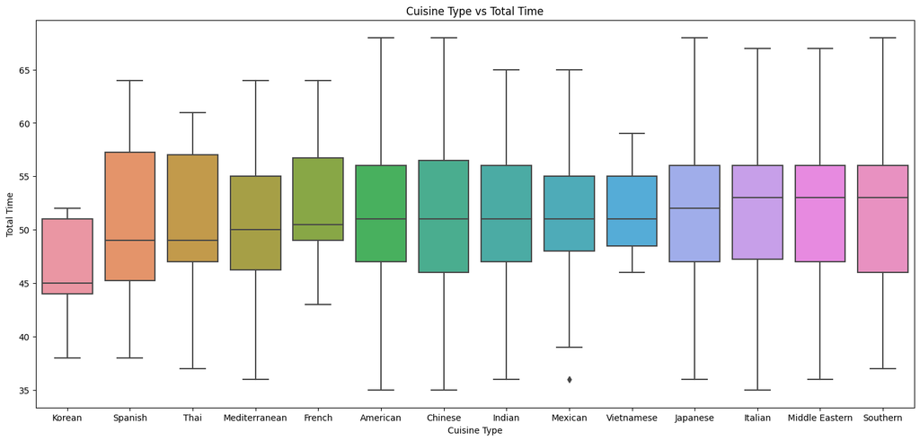

```python
fig, ax = plt.subplots(figsize=(18,8))

sns.boxplot(data=total_time, x="cuisine_type", y="total_time", order=total_time_order, ax=ax)

ax.set_xlabel("Cuisine Type")
ax.set_ylabel("Total Time")
ax.set_title("Cuisine Type vs Total Time")
plt.show()
```

```python
total_time.groupby("cuisine_type")["total_time"].mean().sort_values().head(3).reset_index()
```

|  | cuisine_type | total_time |
| --- | --- | --- |
| 0 | Korean | 46.384615 |
| 1 | Spanish | 50.333333 |
| 2 | Thai | 50.473684 |

Korean cuisine type with the lowest total time, followed by the Spanish and Thai cuisine types.

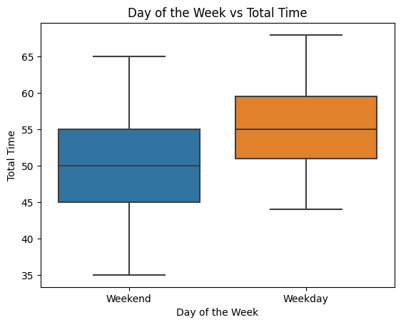

```python
fig, ax = plt.subplots()

sns.boxplot(data=total_time, x="day_of_the_week", y="total_time", ax=ax)

ax.set_xlabel("Day of the Week")
ax.set_ylabel("Total Time")
ax.set_title("Day of the Week vs Total Time")
plt.show()
```

```python
df.groupby("day_of_the_week")["food_preparation_time"].mean()
```

```
day_of_the_week
Weekday    27.212066
Weekend    27.436714
Name: food_preparation_time, dtype: float64
```

```python
df.groupby("day_of_the_week")["delivery_time"].mean()
```

```
day_of_the_week
Weekday    28.340037
Weekend    22.470022
Name: delivery_time, dtype: float64
```

The data reveals that **total delivery time is shorter on weekends**, even though demand is higher during that period. On average, delivery times are approximately **6 minutes faster** on weekends compared to weekdays. This could be attributed to lighter traffic and reduced work-related activity during weekends.

### Conclusions and Recommendations

#### Conclusions

- **Top Restaurants**: **Shake Shack**, **The Meatball Shop** and **Blue Ribbon chain restaurant**. They stand with the most orders (219, 132, 292), and therefore more revenues (3579.53 , 2145.21, 4784.07) . For the most rated restaurants, they also outstand with ratings over 4. The top 20 customers prefer the mentioned restaurants over the rest. The prices of the orders are around the 11 to 20 dollars interval. They maintain optimal food preparation and delivery times.
- **Prefered Cuisine**: The prefered cuisine type is the **American style**, but the top 20 customers prefer the **Japanese style** slightly more. They both maintain prices around the 16 dollars. The Italian and Chinese cuisine is one to keep an eye on as well.
- **Cost of the order**: The cost of the order is on average **16.50 dollars** across all restaurants. However, **Korean and Vietnamese average cost are the lowest of all**, with a median value of 12 dollars. French cuisine type is the most expensive, with a median of 20 dollars.
- There is **lack of significant correlation between cost of the order and food preparation and delivery time**. Internal factors within the restaurant, such as increased demand or other operational considerations may be the root cause of the increased food preparation and delivery times.
- **Prefered Day of the Week**: **Weekend** is the prefered moment to make orders for the customers. Customers have placed 1351 orders on weekend compared to 547 orders on weekdays. Probably customers choose to relax or minimize the activity during weekends.
- **Ratings**: **Spanish cuisine** receives the highest ratings, albeit representing a small portion of the dataset.
- There seems to be **no correlation between rating and food preparation time and cost of the order**. Other factors seem to influence ratings beyond these basic metrics.
- **Preparation and Delivery times**: **Korean cuisine** consistently exhibits shorter preparation and delivery times. (25 and 20 minutes respectively).
- **Delivery times generally tend to be shorter on weekends** (22 minutes on weekends, compared to 28 minutes on weekdays), possibly due to lighter traffic during those days.
- **Food preparation times are similar across the week** (around 28 minutes).

#### Recommendations

- Consider strategies to minimize “Not given” ratings. By reducing instances of “Not Given” ratings, the food aggregator company can effectively identify the highest-rated restaurants. This could enable the implementation of targeted strategies to enhance overall performance.
- Consider focused marketing efforts for renowned establishments such as Blue Ribbon, RedFarm, Shake Shack, and The Meatball Shop. These restaurants consistently demonstrate high revenues, high order volumes, and overall good ratings.
- Leverage the overall preparation, delivery time and average low costs associated with Korean cuisine as a unique selling point. Highlighting efficient service can contribute to making Korean dishes more popular among customers.
- Develop marketing strategies specifically aimed at increasing weekend orders. Emphasize shorter delivery times during weekends, leveraging the lighter traffic conditions to attract more customers.
- Given their exceptional ratings, explore targeted promotional efforts to elevate the popularity of Spanish cuisine. Highlight the distinctive flavors and quality associated with Spanish dishes.